# Titanic data exploration markdown

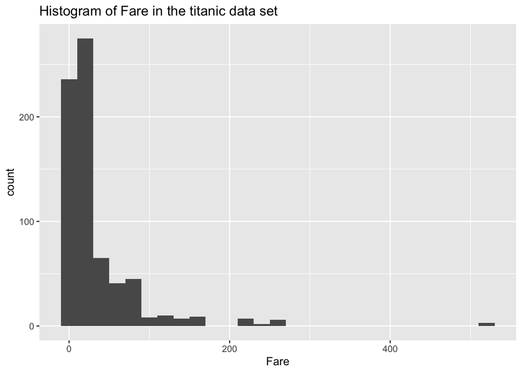

```r
titanic %>% ggplot() +
  geom_histogram(aes(x=Fare),binwidth = 20) +
  ggtitle('Histogram of Fare in the titanic data set')
```

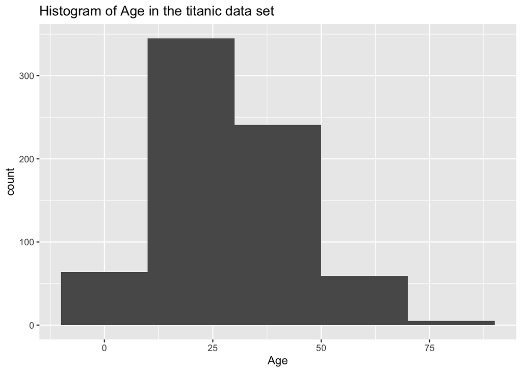

```r
# create a new histogram of Age using the following template

titanic %>% ggplot() +
 geom_histogram(aes(x=Age),binwidth = 20) +
 ggtitle('Histogram of Age in the titanic data set')
```

compute var and sd for the Age column. you can copy paste the code that is doing the same for Fare.

```r
#base R
var(titanic$Fare)
```

```
## [1] 2800.413
```

```r
sd(titanic$Fare)
```

```
## [1] 52.91893
```

```r
var(titanic$Age)
```

```
## [1] 211.0191
```

```r
sd(titanic$Age)
```

```
## [1] 14.5265
```

```r
#tidyverse
titanic %>% pull(Fare) %>% var()
```

```
## [1] 2800.413
```

```r
titanic %>% pull(Fare) %>% sd()
```

```
## [1] 52.91893
```

```r
# now you do the same for Age
titanic %>% pull(Age) %>% var()
```

```
## [1] 211.0191
```

```r
titanic %>% pull(Age) %>% sd()
```

```
## [1] 14.5265
```

## 6.3 Rounding

It’s nice to be able to make numeric variables more readable. Consider rounding to improve readability.

again here try replicating the code to round the Age column

```r
titanic %>% select(Fare) %>% head()
```

```
##      Fare
## 1  7.2500
## 2 71.2833
## 3  7.9250
## 4 53.1000
## 5  8.0500
## 6 51.8625
```

```r
# rounded
titanic %>% select(Fare) %>% round() %>% head()
```

```
##   Fare
## 1    7
## 2   71
## 3    8
## 4   53
## 5    8
## 6   52
```

```r
# now you try for Age
titanic %>% select(Age) %>% round() %>% head()
```

```
##   Age
## 1  22
## 2  38
## 3  26
## 4  35
## 5  35
## 6  54
```

## 6.4 Understand relationship of multiple variables

Generate correlation coefficients of two numeric variables in a 2x2 matrix cor(X,Y) lies between -1 and 1. zero means no correlation. 1 or -1 indicates full correlation positive value means positive correlation and negative values mean negative relationships Examine the components in the formulation for correlation coefficients cor(X,Y) = cov(X,Y)/(sd(X)*sd(Y)) cov(X,Y) = E[X-E(X)]*E[Y-E(Y)]

no changes needed here. simply run.

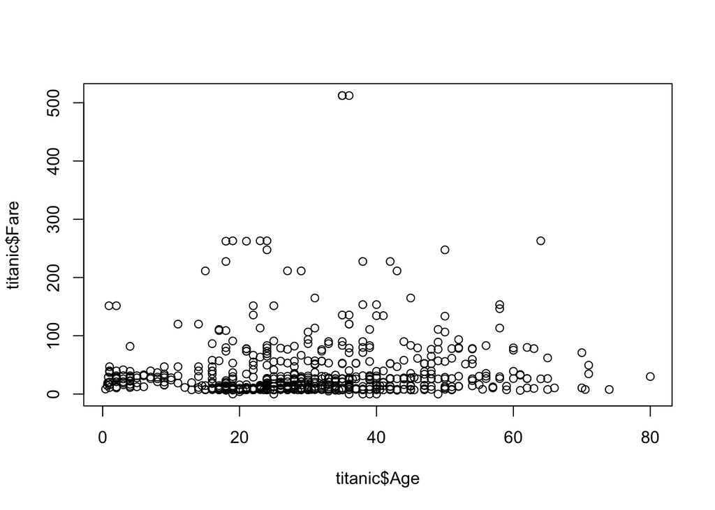

```r
# cor,  boxplot, 2D scatter plot - plot, 3D scatter plot

# scatter plot: two numeric variables
# base R
plot(titanic$Age, titanic$Fare)
```

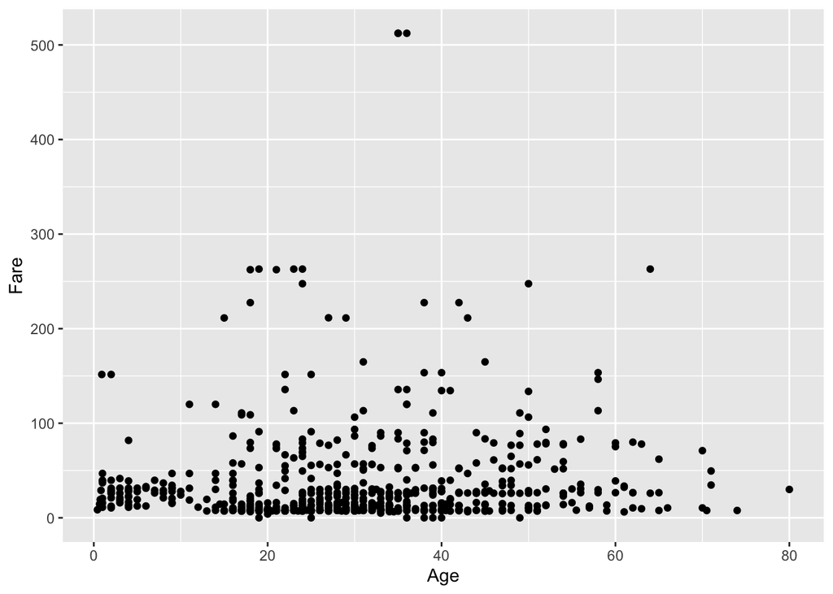

```r
# ggplot
titanic %>% ggplot() +
  geom_point(aes(x=Age,y=Fare))
```

```r
cov(titanic[,c("Fare","Age")]) # this will display incorrect results if missing values are not removed
```

```
##            Fare       Age
## Fare 2800.41310  73.84903
## Age    73.84903 211.01912
```

```r
var(titanic[,c("Fare","Age")])
```

```
##            Fare       Age
## Fare 2800.41310  73.84903
## Age    73.84903 211.01912
```

## 6.5 pairs.panels

demonstrating how to pass only numeric variables to the pairs.panels() function. no changes needed here.

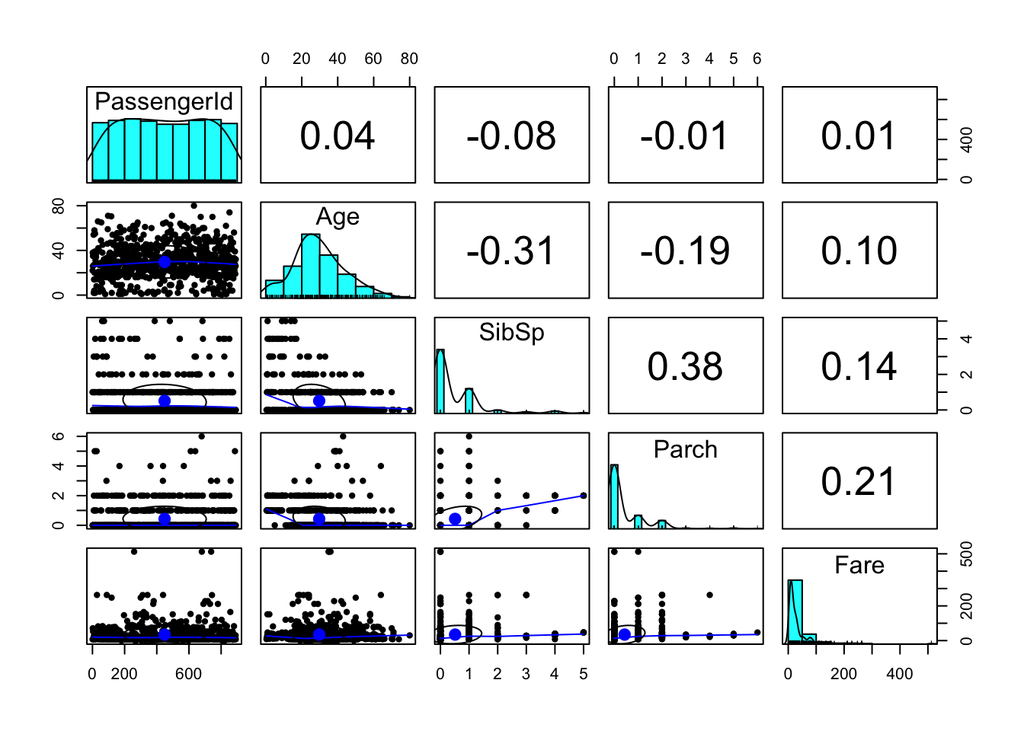

```r
# Generate 2D scatter plots and correlation coefficients
# tidyverse
# select only numeric variables for pairs panels.
titanic %>% select(where(is.numeric)) %>% pairs.panels()
```

# 7 Exploring factor variables

## 7.1 nlevels(), is.factor()

replicate the code to show the levels of Pclass rather than Survived using the nlevels() function.

```r
# A factor's distinct values

# base R
is.factor(titanic$Survived)
```

```
## [1] TRUE
```

```r
nlevels(titanic$Survived)
```

```
## [1] 2
```

```r
# tidy syntax
titanic %>% pull(Survived) %>% nlevels()
```

```
## [1] 2
```

```r
# now you do the same for Pclass
titanic %>% pull(Pclass) %>% nlevels()
```

```
## [1] 3
```

## 7.2 Barplot

replicate the barplot of Pclass for the Sex column. again here just steal the code and swap out the column.

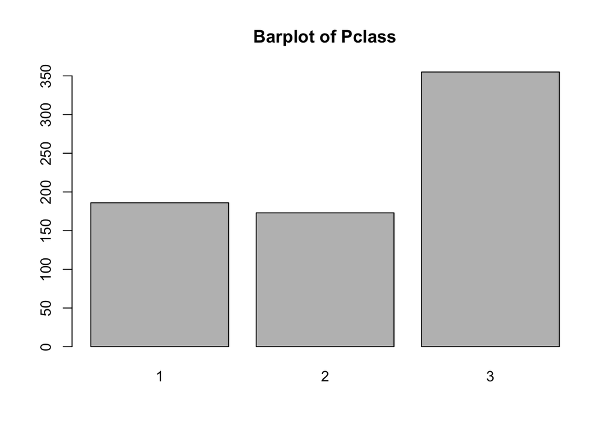

```r
plot(titanic$Pclass,main="Barplot of Pclass")
```

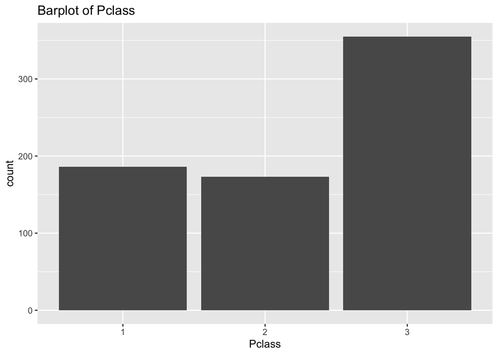

```r
#tidyveryse
titanic %>% ggplot() +
  geom_bar(aes(x=Pclass)) +
  ggtitle("Barplot of Pclass")
```

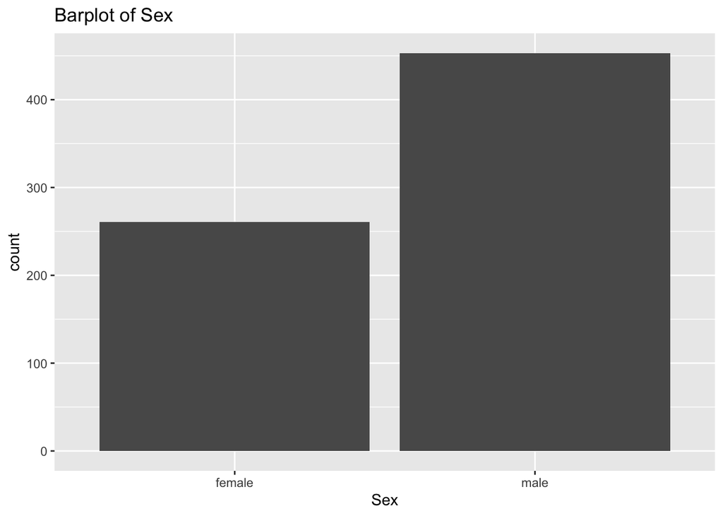

```r
# now you create a barplot for Sex
titanic %>% ggplot() +
  geom_bar(aes(x=Sex)) +
  ggtitle("Barplot of Sex")
```

# Exploring Categorical grouped by Categorical (Factor by Factor)

showing how to get counts for contingency table no changes needed here.

```r
# base R
table(titanic$Survived,titanic$Pclass) # shows the raw counts
```

```
##
##       1   2   3
##   0  64  90 270
##   1 122  83  85
```

```r
prop.table(table(titanic$Survived,titanic$Pclass)) # shows the proportions
```

```
##
##              1          2          3
##   0 0.08963585 0.12605042 0.37815126
##   1 0.17086835 0.11624650 0.11904762
```

```r
prop.table(table(titanic$Survived,titanic$Pclass))*100 # shows the percentages
```

```
##
##             1         2         3
##   0  8.963585 12.605042 37.815126
##   1 17.086835 11.624650 11.904762
```

```r
# sort of tidyverse (ish)
titanic %>% select(Survived,Pclass) %>% table()
```

```
##         Pclass
## Survived   1   2   3
##        0  64  90 270
##        1 122  83  85
```

```r
titanic %>% select(Survived,Pclass) %>% table() %>% prop.table() %>% round(2)
```

```
##         Pclass
## Survived    1    2    3
##        0 0.09 0.13 0.38
##        1 0.17 0.12 0.12
```

```r
titanic %>% select(Survived,Pclass) %>% table() %>% prop.table() %>% round(2) * 100
```

```
##         Pclass
## Survived  1  2  3
##        0  9 13 38
##        1 17 12 12
```

create a barplot of Sex grouped by Survived by copy and pasting the code for Pclass and Survived.

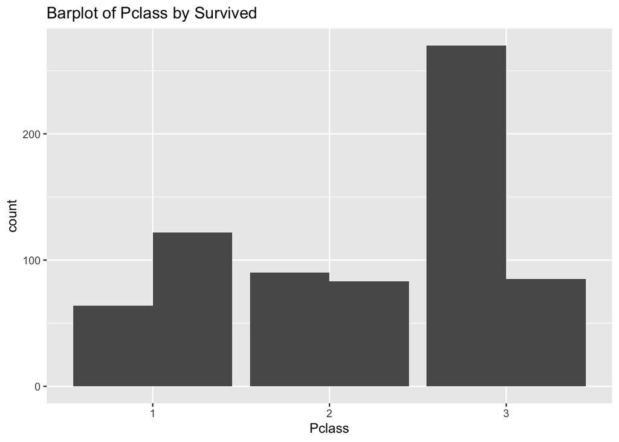

```r
#tidyveryse
titanic %>% ggplot() +
  geom_bar(aes(x=Pclass,group=Survived),position="dodge") +
  ggtitle("Barplot of Pclass by Survived")
```

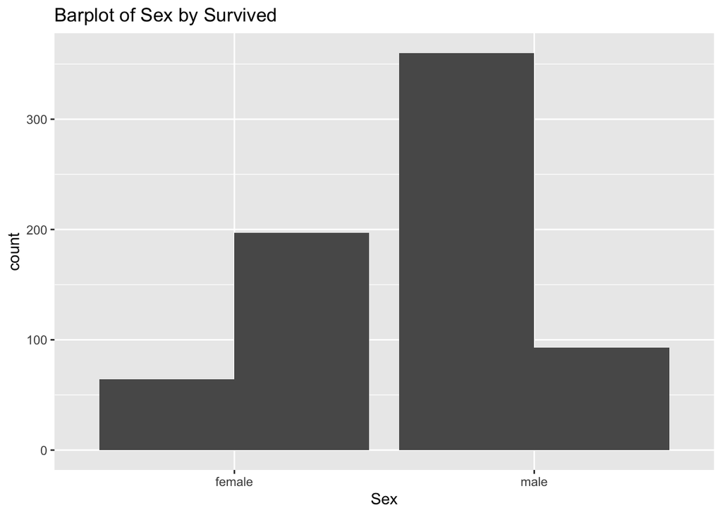

```r
# now you create a barplot for Sex grouped by Survived
titanic %>% ggplot() +
  geom_bar(aes(x=Sex,group=Survived),position="dodge") +
  ggtitle("Barplot of Sex by Survived")
```

Wow! A lot more passengers in Class 3 didn’t survive than those who did. And conversely in Class 1 more passengers survived than did not. In Class 2 it was a bit of a mixed bag.

Often simply looking at a single column is insufficient for the needs of the analysis. Being able to ask the question: When I group the data by a column, how do other columns behave? Is a more interesting and useful EDA task. For example: In the titanic how do the groups of passengers who survived differ from those who did not? Group our data by survived to explore this question.

# 8 Exploring numeric variables by factors

## 8.1 Boxplot

This groups values of a numeric variable based on the values of a factor

simply uncomment the ggplot code to see how to make a boxplot grouped by a categorical variable.

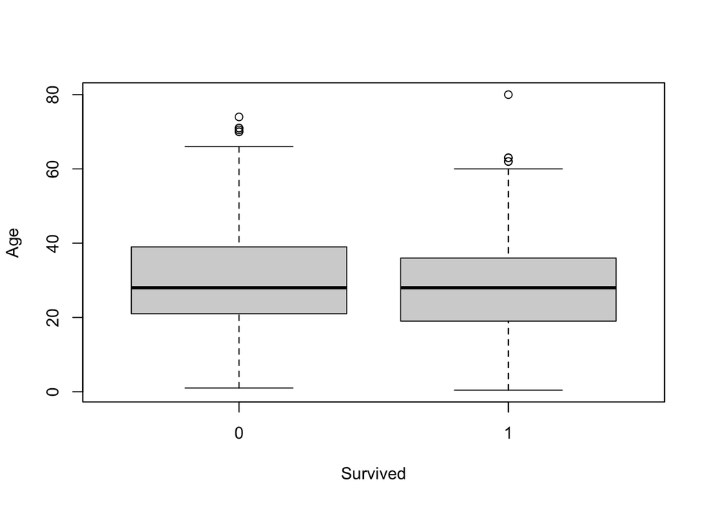

```r
# base R
boxplot(Age~Survived, data = titanic)
```

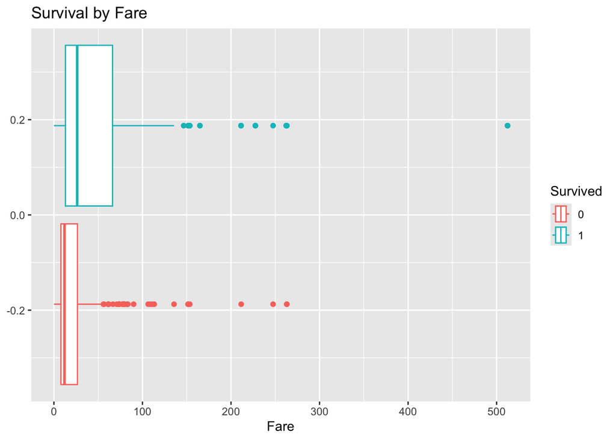

```r
# Below change the graph to display the difference between Survived by Fare

titanic %>%
 ggplot() +
 geom_boxplot(aes(x=Fare,group=Survived,color=Survived)) +
 ggtitle('Survival by Fare')
```

## The aggregate function

no changes needed here. simply run.

```r
# We can use the aggregate command to aggregate a numeric feature by a categorical one.

# The aggregate function has three parameters

# 1. The numeric value, e.g. sales, to be aggregated to find out, e.g., total of sales,
#   average of sales, number of sales (i.e. orders).

# 2. The set of categories, product_category and sales_region, on which you wish
#   to aggregate

# 3.The aggregation function (e.g., sum, mean, length) that you wish to use


# this will not show in output until Knit.
aggregate(Fare~Survived, summary, data = titanic)
```

```
##   Survived Fare.Min. Fare.1st Qu. Fare.Median Fare.Mean Fare.3rd Qu. Fare.Max.
## 1        0   0.00000      7.89580    11.88750  22.96546     26.55000 263.00000
## 2        1   0.00000     13.00000    26.25000  51.84321     66.20000 512.32920
```

```r
#tidyverse

titanic %>%
  group_by(Survived) %>%
  summarize(
    min = min(Fare),
    q1 = quantile(Fare, 0.25),
    median = median(Fare),
    mean = mean(Fare), # adding in mean as well
    q3 = quantile(Fare, 0.75),
    max = max(Fare)
  )
```

```
## # A tibble: 2 × 7
##   Survived   min    q1 median  mean    q3   max
##   <fct>    <dbl> <dbl>  <dbl> <dbl> <dbl> <dbl>
## 1 0            0  7.90   11.9  23.0  26.6  263
## 2 1            0 13      26.2  51.8  66.2  512.
```

## 8.2 Scatter plot of numeric values and factor values

no changes needed here. simply run.

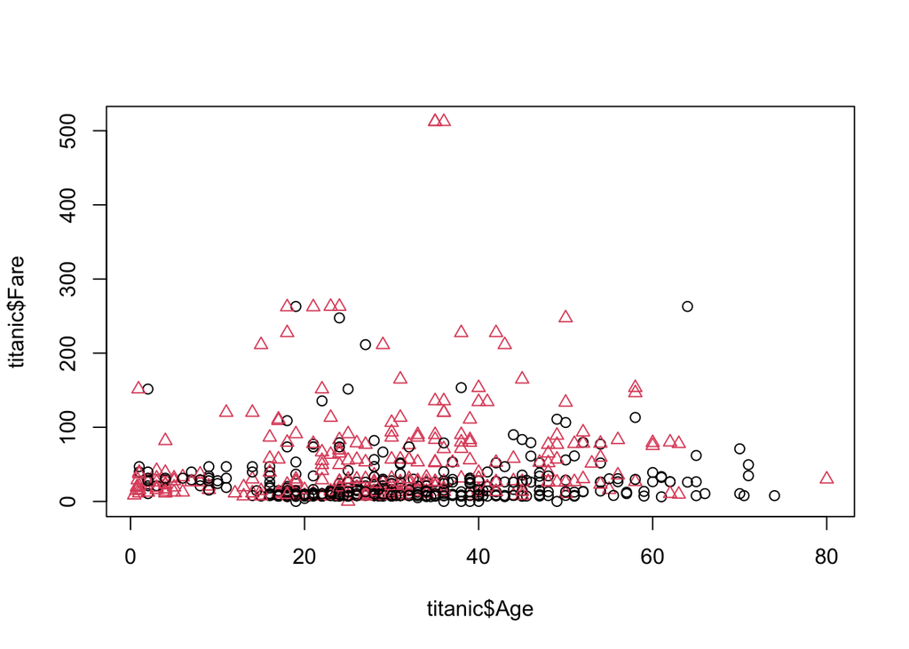

```r
plot(titanic$Age,titanic$Fare, col=titanic$Survived, pch = as.numeric((titanic$Survived)))
```

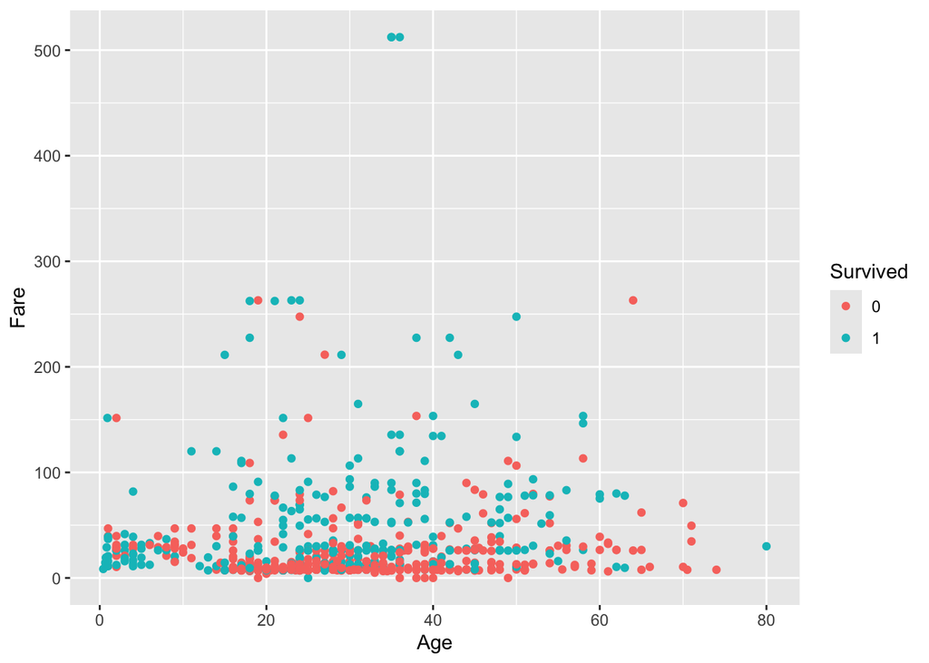

```r
titanic %>% ggplot() + geom_point(aes(x=Age,y=Fare,color=Survived))
```